# TF motif analysis including motif scanning / matching to region of interest

BCL6 LCR paper - script 3.1

Johannes C. Hellmuth

2/6/2020

# Introduction

The following script represents the transcription factor motif-based analysis performed in our recent paper “An OCT2 / OCA-B / MEF2B Ternary Complex Controls the Activity and Architecture of an Essential Locus Control Region for Normal and Malignant Germinal Center B-cells”. This script runs through the following steps for the two TFs we are focusing on, OCT2 (POU2F2) and MEF2B :

- download TF motifs from Jaspar
- trim motifs to remove low information content
- convert the basic Position Count Matrix (PCM) to Position Weight Matrix (PWM)
- search genomic region of interest for matches to PWM motif
- calculate p values for each match

The data generated here (i.e. TF motif matches to the BCL6 locus) are used in the analysis of TF motif density in essential vs non-essential enhancers described in a separate script.  
The script is extensively annotated and can thus be used as a hands-on tutorial for TF motif analysis. Please feel free to email me with any questions, comments or suggestions.  
info at jchellmuth.com

### Load required libraries

```r
library(universalmotif)
library(JASPAR2018)
library(BSgenome.Hsapiens.UCSC.hg38)
library(dplyr)
library(ggplot2)
```

### Get the genomic sequence for the region of interest

Note on nomenclature: this is the ‘search subject’, i.e. the region to be searched for a given motif.  
The region of interest here is the BCL6 locus, losely defined as:  
chr3:187,700,000-188,300,000

```r
hg38 <- BSgenome.Hsapiens.UCSC.hg38
chr3 <- getSeq(hg38,"chr3")
roi <- subseq(chr3,start=187700000,end=188300000)
```

# OCT2 motif analysis

### Motif download

Download TF motif from JASPAR using TFBSTools.  
http://jaspar.genereg.net/matrix/MA0507.1/

```r
# import motif from file:
pfm <- TFBSTools::getMatrixByID(x = JASPAR2018,ID = "MA0507.1")
# check key tags
pfm@tags[c("symbol","description","collection","type","source","species")]
```

```
## $symbol
## [1] "POU2F2"
##
## $description
## [1] "POU class 2 homeobox 2"
##
## $collection
## [1] "CORE"
##
## $type
## [1] "ChIP-seq"
##
## $source
## [1] "ENCODE"
##
## $species
##           9606
## "Homo sapiens"
```

```r
# convert to universalmotif class for easier handling
pfm <- convert_motifs(pfm,class = "universalmotif-universalmotif")
```

### Trim motif

Motifs frequently contain positions with low information content (see non-trimmed motif below). Here, I am using universalmotif’s `trim_motif` to remove edges of motifs with an information content <0.5

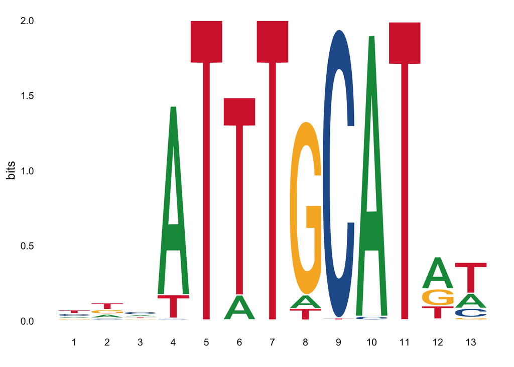

```r
# visualize full motif
view_motifs(pfm)
```

```r
# trim
pfm.trim <- trim_motifs(pfm,min.ic = 0.5)
```

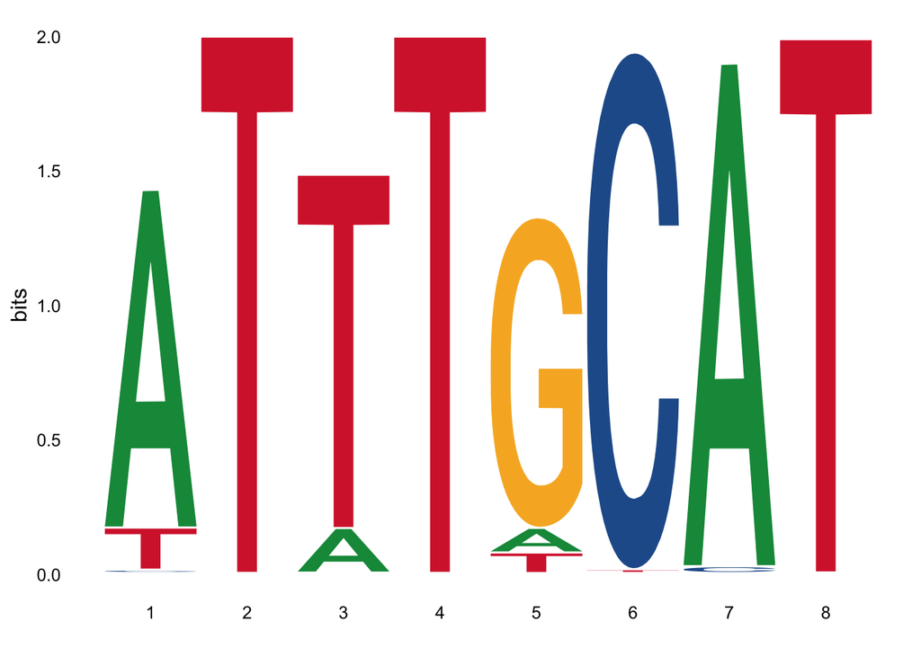

```r
# visualize trimmed motif:
view_motifs(pfm.trim)
```

### Motif representations

There are 3 commonly used TF motif representations:

- Position Frequncy Matrix (PFM) aka Postion Count Matrix (PCM)
- Information Content Matrix (ICM)
- Postion Weight Matrix (PWM) aka Logodds Scoring Matrix

Each of these is informative in a different way and is therefore displayed below.

#### Position Frequency Matrix (PFM) aka Postion Count Matrix (PCM)

This is the most basic representation of a motif and is how the motif is provided by Jaspar.

```r
knitr::kable(pfm.trim@motif,right = F)
```

|  | A | T | T | T | G | C | A | T |
| --- | --- | --- | --- | --- | --- | --- | --- | --- |
| A | 2016 | 0 | 256 | 0 | 158 | 0 | 2257 | 0 |
| C | 19 | 0 | 2 | 0 | 0 | 2271 | 30 | 2 |
| G | 1 | 0 | 0 | 0 | 1997 | 0 | 0 | 0 |
| T | 251 | 2287 | 2029 | 2287 | 132 | 16 | 0 | 2285 |

#### Information Content Matrix (ICM)

ICMs are usually used to represent the motif as a probability sequence logo (as above). The height of the letters represent their probabilities at each position. The ICM has a column sum between 0 (no base preference) and 2 (only 1 base used).

```r
icm <- convert_type(pfm.trim,type = "ICM")
knitr::kable(icm@motif)
```

|  | A | T | T | T | G | C | A | T |
| --- | --- | --- | --- | --- | --- | --- | --- | --- |
| A | 1.2560832 | 0.000218 | 0.1659172 | 0.000218 | 0.0915148 | 0.0002115 | 1.8698794 | 0.0002170 |
| C | 0.0119924 | 0.000218 | 0.0014568 | 0.000218 | 0.0001446 | 1.9217363 | 0.0250587 | 0.0019526 |
| G | 0.0007787 | 0.000218 | 0.0001619 | 0.000218 | 1.1549947 | 0.0002115 | 0.0002071 | 0.0002170 |
| T | 0.1565237 | 1.994559 | 1.3139025 | 1.994559 | 0.0764792 | 0.0137494 | 0.0002071 | 1.9831807 |

#### Postion Weight Matrix (PWM) aka Logodds Scoring Matrix

PWMs are generally used to evaluate how well a sequence matches a motif. Thus, use PWM for `scan_sequences` below.  
Following Nishida et al. Nucleic Aciids Research 2009, a pseudocount of 0.8 is added for conversion to PWM.

```r
pwm <- convert_type(pfm.trim,type = "PWM",pseudocount = 0.8)
knitr::kable(pwm@motif)
```

|  | A | T | T | T | G | C | A | T |
| --- | --- | --- | --- | --- | --- | --- | --- | --- |
| A | 1.817678 | -11.481673 | -1.158619 | -11.481673 | -1.854139 | -11.481673 | 1.980573 | -11.481673 |
| C | -4.896711 | -11.481673 | -8.022242 | -11.481673 | -11.481673 | 1.989494 | -4.243269 | -8.022242 |
| G | -8.896711 | -11.481673 | -11.481673 | -11.481673 | 1.804018 | -11.481673 | -11.481673 | -11.481673 |
| T | -1.187053 | 1.999622 | 1.826950 | 1.999622 | -2.113167 | -5.141823 | -11.481673 | 1.998360 |

### Search for motif in region of interest

From the universalmotif vignette: Given a motif of length n, scan_sequences() considers every possible n-length subset in a sequence and scores it using the PWM format. If the match surpasses the minimum threshold, it is reported.  
For now, I am using a low threshold. Which thershold / match to consider significant is a complex question and will be dealt with in downstream analysis.

```r
# scan sequence for matches:
res <- scan_sequences(pwm,DNAStringSet(roi),threshold = 0.75,threshold.type = "logodds",RC = T,verbose = 0)
```

Correct match coordinates by adding the genomic coordinate of the start pos of the region of interest. and add chromosome name.

```r
res$start <- res$start+187700000-1
res$stop <- res$stop+187700000-1
res$sequence <- "chr3"
```

### Calculate p-values

P-value calculation as per universalMotif Vignette:  
https://bioconductor.org/packages/release/bioc/vignettes/universalmotif/inst/doc/MotifComparisonAndPvalues.pdf  
Note: smaller k leads to faster but worse approximations, and larger k leads to slower but better approximations. If k is equal to the width of the motif, then the calculation is exact.

```r
# get background nucleotide frequency:
bkg <- Biostrings::oligonucleotideFrequency(roi,width = 1,as.prob = T)
# calculate p values:
res$pvalue <- motif_pvalue(pwm, res$score, bkg.probs = bkg,k = 8)
```

### Modify results object

For minus strand hits produced by `scan_sequences`, the ‘start’ position of after the ’end position. To make these genomic positions work in bed files and UCSC, I will flip start and stop positions for minus strand hits.

```r
minus <- res$strand=="-"
res[minus, c("start", "stop")] <- res[minus, c("stop", "start")]
```

Similarly, add the reverse complement of hits on the minus strand.

```r
res$match.stranded <- res$match
res$match.stranded[minus] <- reverseComplement(DNAStringSet(res$match.stranded[minus]))
```

Save results for later analysis

```r
# save results:
save(pwm,file = "OCT2_MA0507.1_PWM.Rda")
save(res,file = "BCL6locus-matches_OCT2_MA0507.1.Rda")
```

### Cutoff evaluation

The question of which match is to be considered significant or biologically relevant is difficult to answer and will depend on things like the type of analysis, the TF at hand or chromatin context.  
The following chunk is meant to give a rough overview of how relative match scores (`score.pct` in the scan_sequences results) relate to PWM scores and p-values (an vice versa).

```r
df <- data.frame(rel.score=c(0.75,0.8,0.85,0.9,0.95,0.99,1))
df$pwm.score <- motif_score(pwm,df$rel.score)
df$pvalue <- motif_pvalue(pwm,score = df$pwm.score)
knitr::kable(df)
```

| rel.score | pwm.score | pvalue |
| --- | --- | --- |
| 0.75 | -10.75675 | 0.0082550 |
| 0.80 | -5.52300 | 0.0044250 |
| 0.85 | -0.28925 | 0.0010376 |
| 0.90 | 4.94450 | 0.0003815 |
| 0.95 | 10.17825 | 0.0000763 |
| 0.99 | 14.36525 | 0.0000153 |
| 1.00 | 15.41200 | 0.0000000 |

The following chunk gives you example matches at different threshold.

```r
res$cut <- cut(res$score.pct,breaks = c(75,80,85,90,95,99,100))
res %>% group_by(cut) %>% top_n(-1,score.pct) %>% filter(!duplicated(score.pct)) %>% arrange(score.pct) %>% ungroup() %>% select(-cut) %>% knitr::kable()
```

| motif | sequence | start | stop | score | max.score | score.pct | match | strand | pvalue | match.stranded |
| --- | --- | --- | --- | --- | --- | --- | --- | --- | --- | --- |
| POU2F2 | chr3 | 187700654 | 187700661 | -9.955 | 15.41557 | 75.21742 | TTAGGCCT | + | 0.0135559 | TTAGGCCT |
| POU2F2 | chr3 | 187749361 | 187749368 | -5.058 | 15.41557 | 80.00093 | GTCTGCAT | + | 0.0071330 | GTCTGCAT |
| POU2F2 | chr3 | 187717154 | 187717161 | 0.842 | 15.41557 | 85.76419 | GTTTTCAT | + | 0.0018727 | GTTTTCAT |
| POU2F2 | chr3 | 187711693 | 187711700 | 5.275 | 15.41557 | 90.09445 | ATTTTCCT | + | 0.0006622 | ATTTTCCT |
| POU2F2 | chr3 | 187740876 | 187740883 | 11.496 | 15.41557 | 96.17127 | ATTTTCAT | + | 0.0001145 | ATTTTCAT |
| POU2F2 | chr3 | 187707731 | 187707738 | 15.411 | 15.41557 | 99.99553 | ATTTGCAT | + | 0.0000262 | ATTTGCAT |

# MEF2B motif analysis

Analysis as above but w/o annotation. ### Motif download http://jaspar.genereg.net/matrix/MA0660.1/

```r
# import motif from file:
pfm <- TFBSTools::getMatrixByID(x = JASPAR2018,ID = "MA0660.1")
# check key tags
pfm@tags[c("remap_tf_name","collection","type","source","species")]
```

```
## $remap_tf_name
## [1] "MEF2B"
##
## $collection
## [1] "CORE"
##
## $type
## [1] "HT-SELEX"
##
## $source
## [1] "23332764"
##
## $species
##           9606
## "Homo sapiens"
```

```r
# convert to universalmotif class for easier handling
pfm <- convert_motifs(pfm,class = "universalmotif-universalmotif")
```

### Trim motif

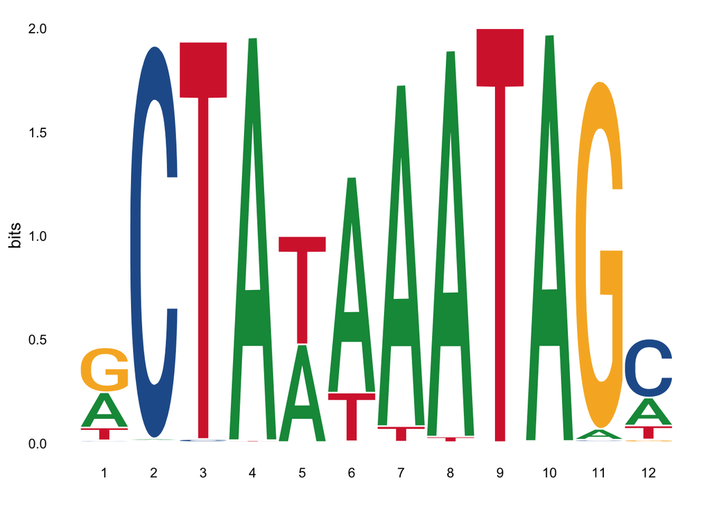

```r
# visualize full motif
view_motifs(pfm)
```

```r
# trim
pfm.trim <- trim_motifs(pfm,min.ic = 0.5)
```

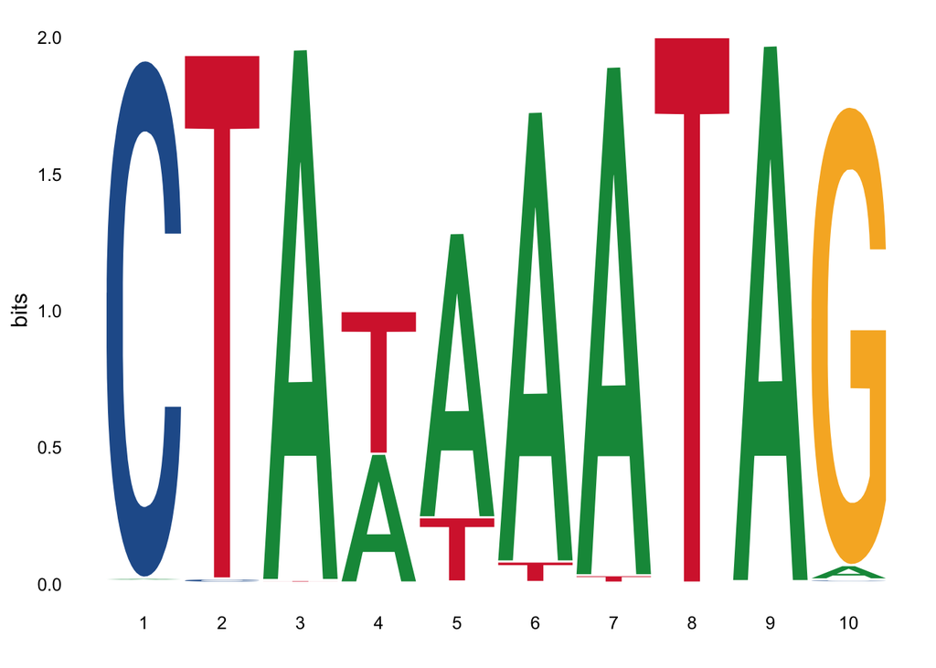

```r
# visualize trimmed motif:
view_motifs(pfm.trim)
```

### Motif representations

#### Position Frequency Matrix (PFM) aka Postion Count Matrix (PCM)

```r
knitr::kable(pfm.trim@motif,right = F)
```

|  | C | T | A | W | A | A | A | T | A | G |
| --- | --- | --- | --- | --- | --- | --- | --- | --- | --- | --- |
| A | 21 | 0 | 3710 | 1768 | 3032 | 3561 | 3675 | 0 | 3718 | 112 |
| C | 3693 | 29 | 0 | 2 | 0 | 3 | 0 | 0 | 4 | 22 |
| G | 0 | 0 | 0 | 0 | 12 | 2 | 0 | 0 | 2 | 3591 |
| T | 14 | 3699 | 18 | 1958 | 684 | 162 | 53 | 3728 | 4 | 3 |

#### Information Content Matrix (ICM)

```r
icm <- convert_type(pfm.trim,type = "ICM")
knitr::kable(icm@motif)
```

|  | C | T | A | W | A | A | A | T | A | G |
| --- | --- | --- | --- | --- | --- | --- | --- | --- | --- | --- |
| A | 0.0108964 | 0.0001295 | 1.9435226 | 0.4714365 | 1.0412121 | 1.6469185 | 1.8627202 | 0.0001339 | 1.9614370 | 0.0524562 |
| C | 1.8937980 | 0.0151530 | 0.0001310 | 0.0005999 | 0.0000858 | 0.0015030 | 0.0001267 | 0.0001339 | 0.0022419 | 0.0103978 |
| G | 0.0001282 | 0.0001295 | 0.0001310 | 0.0000667 | 0.0042064 | 0.0010405 | 0.0001267 | 0.0001339 | 0.0011869 | 1.6782495 |
| T | 0.0073070 | 1.9164031 | 0.0095598 | 0.5220928 | 0.2349573 | 0.0750334 | 0.0269886 | 1.9965197 | 0.0022419 | 0.0015188 |

#### Postion Weight Matrix (PWM) aka Logodds Scoring Matrix

```r
pwm <- convert_type(pfm.trim,type = "PWM",pseudocount = 0.8)
knitr::kable(pwm@motif)
```

|  | C | T | A | W | A | A | A | T | A | G |
| --- | --- | --- | --- | --- | --- | --- | --- | --- | --- | --- |
| A | -5.458503 | -12.186424 | 1.992786 | 0.923570 | 1.7016535 | 1.933652 | 1.979111 | -12.186424 | 1.995893 | -3.054567 |
| C | 1.986160 | -4.996599 | -12.186424 | -8.726992 | -12.1864238 | -8.186424 | -12.186424 | -12.186424 | -7.794106 | -5.392008 |
| G | -12.186424 | -12.186424 | -12.186424 | -12.186424 | -6.2556865 | -8.726992 | -12.186424 | -12.186424 | -8.726992 | 1.945755 |
| T | -6.036677 | 1.988502 | -5.678629 | 1.070817 | -0.4462214 | -2.522866 | -4.131141 | 1.999768 | -7.794106 | -8.186424 |

### Search for motif in region of interest

```r
# scan sequence for matches:
res <- scan_sequences(pwm,DNAStringSet(roi),threshold = 0.75,threshold.type = "logodds",RC = T,verbose = 0)
```

```r
res$start <- res$start+187700000-1
res$stop <- res$stop+187700000-1
res$sequence <- "chr3"
```

### Calculate p-values

```r
# get background nucleotide frequency:
bkg <- Biostrings::oligonucleotideFrequency(roi,width = 1,as.prob = T)
# calculate p values:
res$pvalue <- motif_pvalue(pwm, res$score, bkg.probs = bkg,k = 8)
```

### Modify results object

```r
minus <- res$strand=="-"
res[minus, c("start", "stop")] <- res[minus, c("stop", "start")]
```

```r
res$match.stranded <- res$match
res$match.stranded[minus] <- reverseComplement(DNAStringSet(res$match.stranded[minus]))
```

```r
# save results:
save(pwm,file = "MEF2B_MA0660.1_PWM.Rda")
save(res,file = "BCL6locus-matches_MEF2B_MA0660.1.Rda")
```

### Cutoff evaluation

```r
df <- data.frame(rel.score=c(0.75,0.8,0.85,0.9,0.95,0.99,1))
df$pwm.score <- motif_score(pwm,df$rel.score)
df$pvalue <- motif_pvalue(pwm,score = df$pwm.score)
knitr::kable(df)
```

| rel.score | pwm.score | pvalue |
| --- | --- | --- |
| 0.75 | -13.79400 | 0.0060081 |
| 0.80 | -7.31760 | 0.0018015 |
| 0.85 | -0.84120 | 0.0004683 |
| 0.90 | 5.63520 | 0.0000858 |
| 0.95 | 12.11160 | 0.0000095 |
| 0.99 | 17.29272 | 0.0000019 |
| 1.00 | 18.58800 | 0.0000000 |

```r
res$cut <- cut(res$score.pct,breaks = c(75,80,85,90,95,99,100))
res %>% group_by(cut) %>% top_n(-1,score.pct) %>% filter(!duplicated(score.pct)) %>% arrange(score.pct) %>% ungroup() %>% select(-cut) %>% knitr::kable()
```

| motif | sequence | start | stop | score | max.score | score.pct | match | strand | pvalue | match.stranded |
| --- | --- | --- | --- | --- | --- | --- | --- | --- | --- | --- |
| MEF2B | chr3 | 187926606 | 187926615 | -13.206 | 18.59354 | 75.00016 | CTTTCTTTAG | + | 0.0108889 | CTTTCTTTAG |
| MEF2B | chr3 | 188055725 | 188055734 | -6.846 | 18.59354 | 80.00020 | GCAAATATAG | + | 0.0035803 | GCAAATATAG |
| MEF2B | chr3 | 188233541 | 188233550 | -0.469 | 18.59354 | 85.01361 | CTATGATTAA | + | 0.0009354 | CTATGATTAA |
| MEF2B | chr3 | 188247283 | 188247292 | 5.878 | 18.59354 | 90.00343 | CTATTTTTAG | + | 0.0001938 | CTATTTTTAG |
| MEF2B | chr3 | 188145045 | 188145054 | 12.333 | 18.59354 | 95.07815 | CTAATTTTAG | - | 0.0000208 | CTAAAATTAG |
| MEF2B | chr3 | 188291474 | 188291483 | 18.441 | 18.59354 | 99.88008 | CTAAAAATAG | + | 0.0000021 | CTAAAAATAG |